# Longitudinal Mixed-Model Calibration Simulation (Goal 5a)

`mlmRev::egsingle` two-stage hierarchical plasmode resampling

2026-11-18

# 1 Purpose

This report documents Goal 5a of the RESI mixed-model extension project (see `instructions/instructions.md` at the repository root): a calibration check of the mixed-model RESI point estimator and of the fixed-effect standard errors for `lme4::lmer`, using a **hybrid plasmode simulation** built on `mlmRev::egsingle`. The simulation is implemented by `RESI::hybridPlasmodeSim()` (`RESI/R/mixed_simulations.R`) and run by `tests/run_hybrid_plasmode.R`.

**Why not resample the real outcomes?** An earlier full two-stage bootstrap of the real data (schools, then children, with replacement, keeping the observed outcomes) gave model-based fixed-effect SEs that stayed well below the Monte Carlo SD for child- and occasion-level covariates, and a growing bias in the school variance. Simon’s hypothesis is that real slope heterogeneity across schools and children, which Model A does not include, inflates the true sampling variability when real outcomes are resampled. Consistent with this, outcomes generated from the fitted Model A were correctly calibrated. The hybrid plasmode therefore resamples the covariate design hierarchically but generates new outcomes from the fitted model.

# 2 Dataset: `mlmRev::egsingle`

`egsingle` is a 3-level growth-curve dataset (measurement occasion nested in child nested in school) used as the plasmode base because it is the only dataset found (across `lme4`, `nlme`, `geepack`, `mlmRev`, `JM`, `joineR`, `merTools`) with >=1000 independent subjects, a continuous repeated-measures outcome, and a continuous time covariate suitable for a smooth term.

## 2.1 Overall size

Overall dataset size

| Quantity | N |
| --- | --- |
| Schools | 60 |
| Children | 1721 |
| Measurement occasions (rows) | 7230 |

## 2.2 Children per school

Distribution of children per school (60 schools)

| Min | 1st Qu. | Median | Mean | 3rd Qu. | Max | SD |
| --- | --- | --- | --- | --- | --- | --- |
| 5 | 15.75 | 24 | 28.68 | 40.25 | 89 | 18.13 |

Every one of the 60 schools has at least 5 children, up to 89, with a mean of 28.7 and median of 24 children per school (SD 18.1) – a right-skewed, moderately variable cluster-size distribution, which is why the plasmode resampling below draws each school’s *own* number of children (not a fixed number) when it is resampled.

## 2.3 Variables

egsingle variables and nesting structure

| Variable | Level | Type | Description |
| --- | --- | --- | --- |
| schoolid | 3 (school, n=60) | factor | school identifier |
| childid | 2 (child, n=1721) | factor | child identifier, nested in school |
| year | 1 (occasion, n=7230 rows) | continuous | time, centered (range -2.5 to 2.5, integer steps) |
| grade | 1 (occasion) | continuous (0-4) | grade level, collinear with year |
| math | 1 (occasion) | continuous | outcome: math achievement score |
| retained | 1 (occasion) | binary factor | held back a grade (mostly time-invariant) |
| female | 2 (child) | binary factor | child sex |
| black | 2 (child) | binary factor | child race indicator |
| hispanic | 2 (child) | binary factor | child ethnicity indicator |
| size | 3 (school) | continuous | school enrollment size |
| lowinc | 3 (school) | continuous | % low income at school |
| mobility | 3 (school) | continuous | % student mobility at school |

# 3 Simulation design

## 3.1 Fixed-divisor covariate rescaling

`size` (school enrollment, range 113-1486, SD 312.6) is on a very different scale from the other covariates and caused an `lme4` convergence warning when used raw. Both `size` and `lowinc` are rescaled by a **fixed divisor** (not a z-score), applied identically to every replicate, so coefficients stay directly interpretable:

- `size_100 = size / 100` (school enrollment in hundreds of students)
- `lowinc_10 = lowinc / 10` (percent low-income in units of 10 percentage points)

Combined with `lmerControl(optimizer = "bobyqa", optCtrl = list(maxfun = 2e5))`, Model A fits with 0 convergence warnings on the full data.

## 3.2 Model A

`math ~ year + female + black + hispanic + size_100 + lowinc_10 + (1 | schoolid/childid)`

The full-sample Model A fit uses ML (`REML = FALSE`) and supplies the plug-in generating parameters and full-sample reference. Each simulated Model A fit uses REML (`REML = TRUE`). Thus the replicate estimator is REML while the full-sample target/generating fit is ML; interpret finite-sample differences with that distinction in mind.

Random-effect (variance component) standard errors are **not** computed; only fixed-effect model-based SEs are compared against the Monte Carlo SD of each fixed effect across replicates. Variance-component point estimates are still tracked for bias.

# 4 Hybrid plasmode (hierarchical covariate and BLUP resampling)

## 4.1 Motivation and method

This hybrid plasmode resamples the covariate design hierarchically from the real data, then generates fresh random effects and residuals from the fitted Model A generator. This retains the empirical joint covariate distribution across schools and students without carrying over the real outcomes.

For each replicate, draw `n_schools` source schools with replacement from the 60 observed schools. Within each selected source school, draw students with replacement. If source school $i$ contains $m_i$ observed students, draw approximately $n_{per\_site} m_i / \bar m$ students, where $\bar m$ is the average observed school size. Thus expected sample size is proportional to source-school size and the average number drawn per generated school is approximately `n_per_site`; rounding makes the realized total vary slightly. Each selected student contributes all of their observed measurement rows. Every school and student draw receives a new ID, even when the same source school or student is selected more than once. This sampling is with replacement and occurs anew for every replicate.

Raw BLUPs are shrunk toward zero relative to the true random-effect variance (a well-known property of best linear unbiased prediction), so each BLUP pool is first centered to exactly mean zero and then rescaled so its variance equals the corresponding fitted variance component before any resampling:
$$b^*_i = (b_i - \bar b) \times \sqrt{\hat\sigma^2 \Big/ \tfrac{1}{G}\textstyle\sum_i (b_i - \bar b)^2}$$
The $1/G$ (population) variance is used because generated units draw with replacement from the pool, so the variance of a draw is exactly $\hat\sigma^2$. (An earlier version used the $1/(G-1)$ sample variance, which built a $(G-1)/G$ shrinkage, $-1.67\%$ for the 60 school BLUPs, into `var_schoolid`.) For Model A fit to the real data: the 60 school BLUPs have raw variance 0.056 (fitted `var_schoolid` = 0.079, so rescale factor $\approx 1.19$); the 1721 child BLUPs have raw variance 0.562 (fitted `var_childid:schoolid` = 0.652, rescale factor $\approx 1.08$). The full-data Model A fit remains ML (`REML = FALSE`) and supplies the plug-in DGP fixed effects and variance components. School and student BLUP pools are centered and rescaled to their fitted variances; each generated school and student receives an independent draw with replacement from its corresponding pool. Fresh residuals are drawn from the fitted Normal residual distribution. Each simulated dataset is refit using REML (`REML = TRUE`); the coefficient and RESI standard errors are model-based, from `stats::vcov`.

The reported grid is `n_schools in {15,30,60,100}` crossed with `n_per_site in {25,100,200}`. The 200-school and 50-student/site conditions are excluded. The simulation sets `set.seed(2026)` once before iterating over grid cells. `mclapply` uses L’Ecuyer-CMRG worker streams with `mc.set.seed = TRUE` for covariate resampling, BLUP resampling, and residual draws.

## 4.2 Results

The short translucent ticks in that row are the finite-sample reference for each cell. Each replicate redraws `n_schools` school profiles, so the Monte Carlo variance of $\hat\beta$ is $E_X[\mathrm{Var}(\hat\beta \mid X)] + \mathrm{Var}_X(E[\hat\beta \mid X])$, and the second term is about zero because $\hat\beta$ is conditionally unbiased. The reference is therefore $\sqrt{n_k E_X[V(X)]_{kk}}$, where $V(X)$ is the GLS covariance of a resampled design at the full-data variance components, averaged over 2000 resampled school sets per cell (`designAveragedSe()` in `RESI/R/mixed_simulations.R`; cached in `design_averaged_se.rds`). It exceeds the SE of the expected design, $\sqrt{n_k [E_X I(X)]^{-1}_{kk}}$, because $E[I^{-1}] \ge E[I]^{-1}$. The gap is largest at small `n_schools` and for covariates concentrated in a few schools (e.g. `hispanic`: 28 of 60 schools have no Hispanic students), and it vanishes as `n_schools` grows. This reference applies to the spread of $\hat\beta$ only. RESI divides by each dataset’s own SE, so its fixed-$m$ reference in the RESI rows remains the expected-design value $S_m$.

mean_model_se / mc_sd by fixed effect, n_schools, and n_per_site (hybrid plasmode, Model A)

| param | n_schools | se_ratio.25 | se_ratio.100 | se_ratio.200 |
| --- | --- | --- | --- | --- |
| beta_(Intercept) | 15 | 0.972 | 0.960 | 0.922 |
| beta_(Intercept) | 30 | 0.972 | 0.987 | 0.940 |
| beta_(Intercept) | 60 | 1.012 | 1.013 | 0.999 |
| beta_(Intercept) | 100 | 0.991 | 1.031 | 1.019 |
| beta_black1 | 15 | 0.963 | 0.997 | 0.984 |
| beta_black1 | 30 | 0.948 | 1.007 | 0.978 |
| beta_black1 | 60 | 0.996 | 0.986 | 0.994 |
| beta_black1 | 100 | 0.990 | 1.018 | 1.021 |
| beta_femaleMale | 15 | 1.035 | 1.002 | 0.973 |
| beta_femaleMale | 30 | 1.026 | 0.979 | 1.014 |
| beta_femaleMale | 60 | 0.991 | 0.998 | 0.968 |
| beta_femaleMale | 100 | 0.992 | 0.983 | 0.996 |
| beta_hispanic1 | 15 | 0.951 | 0.955 | 0.975 |
| beta_hispanic1 | 30 | 1.000 | 0.978 | 0.959 |
| beta_hispanic1 | 60 | 1.002 | 0.963 | 0.963 |
| beta_hispanic1 | 100 | 0.974 | 1.003 | 0.981 |
| beta_lowinc_10 | 15 | 0.971 | 0.960 | 0.954 |
| beta_lowinc_10 | 30 | 0.992 | 1.008 | 0.978 |
| beta_lowinc_10 | 60 | 1.007 | 1.012 | 1.031 |
| beta_lowinc_10 | 100 | 0.975 | 1.025 | 1.005 |
| beta_size_100 | 15 | 0.916 | 0.940 | 0.939 |
| beta_size_100 | 30 | 0.978 | 0.962 | 0.979 |
| beta_size_100 | 60 | 0.981 | 0.965 | 0.992 |
| beta_size_100 | 100 | 0.948 | 1.033 | 1.009 |
| beta_year | 15 | 1.009 | 0.982 | 1.024 |
| beta_year | 30 | 0.997 | 1.006 | 0.968 |
| beta_year | 60 | 1.040 | 0.971 | 1.005 |
| beta_year | 100 | 0.956 | 0.998 | 0.985 |

Fixed-effect Monte Carlo estimates, bias, and scaled standard-error diagnostics

| n_schools | n_per_site | param | truth | mc_mean | bias | mc_sd | mean_model_se | se_n_level | n_scaling | truth_se_scaled | mc_error_sd_scaled | scaled_mc_error_sd_ratio | n_success |
| --- | --- | --- | --- | --- | --- | --- | --- | --- | --- | --- | --- | --- | --- |
| 15 | 25 | beta_(Intercept) | 0.2463 | 0.2582 | -0.0119 | 0.3437 | 0.3342 | schools | 15 | 0.9179 | 1.3311 | 1.4502 | 1000 |
| 15 | 25 | beta_year | 0.7464 | 0.7467 | -0.0003 | 0.0115 | 0.0116 | students | 375 | 0.2239 | 0.2235 | 0.9983 | 1000 |
| 15 | 25 | beta_femaleMale | -0.0029 | -0.0007 | -0.0021 | 0.0888 | 0.0920 | students | 375 | 1.7456 | 1.7204 | 0.9855 | 1000 |
| 15 | 25 | beta_black1 | -0.5114 | -0.5180 | 0.0066 | 0.1867 | 0.1798 | students | 375 | 3.6543 | 3.6159 | 0.9895 | 1000 |
| 15 | 25 | beta_hispanic1 | -0.2867 | -0.2862 | -0.0005 | 0.2168 | 0.2061 | students | 375 | 3.8145 | 4.1977 | 1.1005 | 1000 |
| 15 | 25 | beta_size_100 | -0.0109 | -0.0124 | 0.0015 | 0.0361 | 0.0331 | schools | 15 | 0.0913 | 0.1398 | 1.5322 | 1000 |
| 15 | 25 | beta_lowinc_10 | -0.0796 | -0.0794 | -0.0002 | 0.0411 | 0.0399 | schools | 15 | 0.1062 | 0.1592 | 1.4997 | 1000 |
| 30 | 25 | beta_(Intercept) | 0.2463 | 0.2452 | 0.0012 | 0.2291 | 0.2226 | schools | 30 | 0.9179 | 1.2549 | 1.3672 | 1000 |
| 30 | 25 | beta_year | 0.7464 | 0.7465 | 0.0000 | 0.0082 | 0.0082 | students | 750 | 0.2239 | 0.2243 | 1.0018 | 1000 |
| 30 | 25 | beta_femaleMale | -0.0029 | -0.0041 | 0.0012 | 0.0627 | 0.0643 | students | 750 | 1.7456 | 1.7170 | 0.9836 | 1000 |
| 30 | 25 | beta_black1 | -0.5114 | -0.5145 | 0.0030 | 0.1311 | 0.1243 | students | 750 | 3.6543 | 3.5890 | 0.9821 | 1000 |
| 30 | 25 | beta_hispanic1 | -0.2867 | -0.2884 | 0.0017 | 0.1395 | 0.1395 | students | 750 | 3.8145 | 3.8197 | 1.0014 | 1000 |
| 30 | 25 | beta_size_100 | -0.0109 | -0.0103 | -0.0006 | 0.0225 | 0.0220 | schools | 30 | 0.0913 | 0.1235 | 1.3532 | 1000 |
| 30 | 25 | beta_lowinc_10 | -0.0796 | -0.0795 | -0.0001 | 0.0270 | 0.0268 | schools | 30 | 0.1062 | 0.1479 | 1.3931 | 1000 |
| 60 | 25 | beta_(Intercept) | 0.2463 | 0.2505 | -0.0042 | 0.1520 | 0.1539 | schools | 60 | 0.9179 | 1.1774 | 1.2827 | 1000 |
| 60 | 25 | beta_year | 0.7464 | 0.7461 | 0.0003 | 0.0056 | 0.0058 | students | 1500 | 0.2239 | 0.2155 | 0.9624 | 1000 |
| 60 | 25 | beta_femaleMale | -0.0029 | -0.0035 | 0.0006 | 0.0460 | 0.0456 | students | 1500 | 1.7456 | 1.7807 | 1.0201 | 1000 |
| 60 | 25 | beta_black1 | -0.5114 | -0.5136 | 0.0021 | 0.0871 | 0.0868 | students | 1500 | 3.6543 | 3.3725 | 0.9229 | 1000 |
| 60 | 25 | beta_hispanic1 | -0.2867 | -0.2880 | 0.0013 | 0.0970 | 0.0972 | students | 1500 | 3.8145 | 3.7586 | 0.9854 | 1000 |
| 60 | 25 | beta_size_100 | -0.0109 | -0.0115 | 0.0006 | 0.0153 | 0.0150 | schools | 60 | 0.0913 | 0.1182 | 1.2954 | 1000 |
| 60 | 25 | beta_lowinc_10 | -0.0796 | -0.0796 | 0.0000 | 0.0183 | 0.0185 | schools | 60 | 0.1062 | 0.1421 | 1.3380 | 1000 |
| 100 | 25 | beta_(Intercept) | 0.2463 | 0.2435 | 0.0028 | 0.1187 | 0.1177 | schools | 100 | 0.9179 | 1.1873 | 1.2936 | 1000 |
| 100 | 25 | beta_year | 0.7464 | 0.7465 | 0.0000 | 0.0047 | 0.0045 | students | 2500 | 0.2239 | 0.2344 | 1.0468 | 1000 |
| 100 | 25 | beta_femaleMale | -0.0029 | -0.0026 | -0.0002 | 0.0355 | 0.0352 | students | 2500 | 1.7456 | 1.7766 | 1.0178 | 1000 |
| 100 | 25 | beta_black1 | -0.5114 | -0.5117 | 0.0003 | 0.0674 | 0.0667 | students | 2500 | 3.6543 | 3.3681 | 0.9217 | 1000 |
| 100 | 25 | beta_hispanic1 | -0.2867 | -0.2854 | -0.0013 | 0.0764 | 0.0744 | students | 2500 | 3.8145 | 3.8182 | 1.0010 | 1000 |
| 100 | 25 | beta_size_100 | -0.0109 | -0.0105 | -0.0004 | 0.0121 | 0.0115 | schools | 100 | 0.0913 | 0.1211 | 1.3266 | 1000 |
| 100 | 25 | beta_lowinc_10 | -0.0796 | -0.0795 | 0.0000 | 0.0145 | 0.0141 | schools | 100 | 0.1062 | 0.1447 | 1.3630 | 1000 |
| 15 | 100 | beta_(Intercept) | 0.2463 | 0.2363 | 0.0100 | 0.2919 | 0.2801 | schools | 15 | 0.9179 | 1.1304 | 1.2316 | 1000 |
| 15 | 100 | beta_year | 0.7464 | 0.7464 | 0.0000 | 0.0060 | 0.0059 | students | 1500 | 0.2239 | 0.2307 | 1.0303 | 1000 |

[output cut: 54 more lines]

Variance-component relative bias (%) by n_schools and n_per_site (hybrid plasmode, Model A)

| param | n_schools | rel_bias_pct.25 | rel_bias_pct.100 | rel_bias_pct.200 |
| --- | --- | --- | --- | --- |
| var_childid:schoolid_(Intercept) | 15 | -0.43 | 0.21 | 0.04 |
| var_childid:schoolid_(Intercept) | 30 | 0.04 | -0.02 | -0.03 |
| var_childid:schoolid_(Intercept) | 60 | 0.05 | 0.05 | 0.02 |
| var_childid:schoolid_(Intercept) | 100 | 0.08 | 0.01 | 0.05 |
| var_Residual | 15 | -0.07 | -0.08 | -0.05 |
| var_Residual | 30 | 0.02 | 0.03 | -0.05 |
| var_Residual | 60 | 0.04 | -0.01 | -0.01 |
| var_Residual | 100 | -0.01 | -0.03 | 0.02 |
| var_schoolid_(Intercept) | 15 | 0.07 | -2.09 | -0.08 |
| var_schoolid_(Intercept) | 30 | -0.49 | -0.25 | 1.24 |
| var_schoolid_(Intercept) | 60 | 0.24 | -0.02 | 0.44 |
| var_schoolid_(Intercept) | 100 | -0.15 | 0.61 | 0.17 |

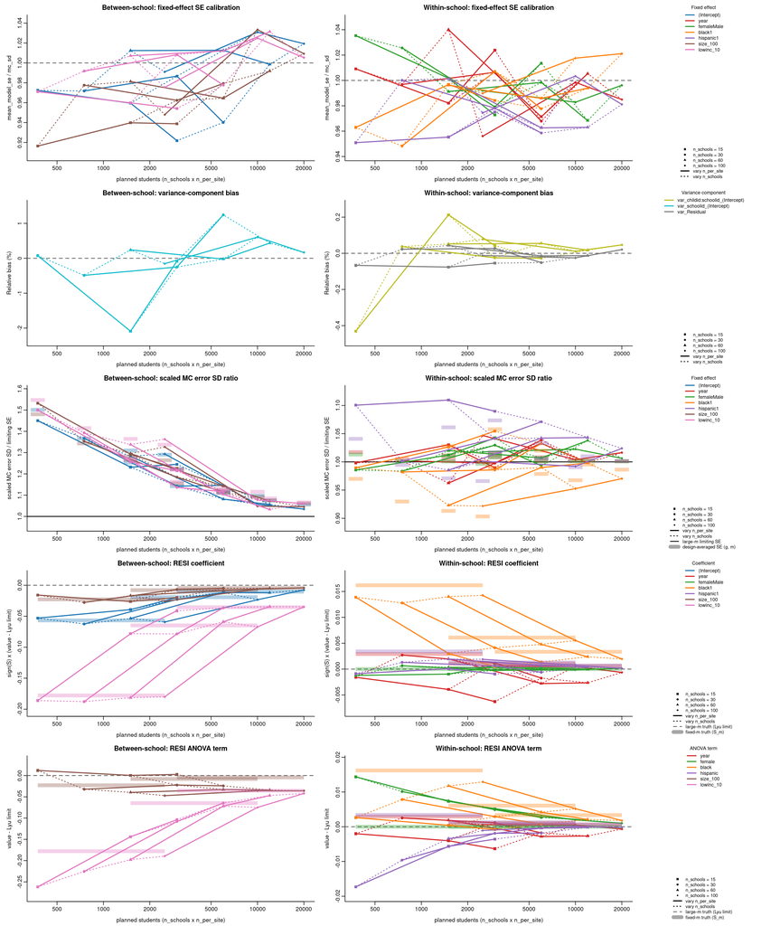

Joint hybrid plasmode calibration across n_schools and n_per_site. Left column: between-school terms (intercept, size_100, lowinc_10, school variance); middle column: terms that vary within school (year, female, black, hispanic, child and residual variances). The x-axis is the planned total student count n_schools x n_per_site (log scale). Solid lines connect n_per_site values at fixed n_schools; dotted lines connect n_schools values at fixed n_per_site; point shape marks n_schools; color marks the term and is shared across rows. Rows: fixed-effect SE ratio, variance-component relative bias, scaled Monte Carlo coefficient-error SD / Lyu-Welsh limiting per-unit SE (solid line at 1 = large-m truth; short translucent ticks = the design-averaged per-unit SE at that n_schools x n_per_site cell divided by the limiting SE, the finite-sample reference for the Monte Carlo SD), and RESI coefficient and ANOVA-term point estimates. In the RESI rows every quantity is centred on the large-m truth (Lyu-Welsh limit from the full-data ML fit, dashed zero line): points are simulation means and the wide translucent bands are the fixed-m truth S_m (exact RESI of the expected design at that n_per_site, constant across n_schools). Coefficients are multiplied by sign(S) so that positive means larger in magnitude in both RESI rows. The gap between points and the zero line is the total bias against the large-m target; the gap between points and the band is estimator bias at fixed m.

## 4.3 RESI point-estimator calibration

RESI is design dependent: for a fixed average cluster size $m$, its value changes with $m$ because the precision of between-school coefficients scales like $g/(\tau^2_{school} + \sigma^2_{w}/m)$, and partly clustered student covariates (e.g. `black`, `hispanic`) borrow between-school information that vanishes as $m$ grows. The calibration target, `truth_resi`, is therefore the Lyu and Welsh (2022, Theorem 1) increasing-cluster-size limit ($g, m \to \infty$), computed from the full-sample Model A ML fit by `lyuLimitResi()` (`RESI/R/mixed_simulations.R`):

- between-school terms (intercept, `size_100`, `lowinc_10`), normalised by $g$: $S_k = \beta_k / \sqrt{\tau^2_{school}[C^{-1}]_{kk}}$, with $C = g^{-1}\sum_s x_s x_s^\top$ over the 60 observed school profiles;
- within-school terms, normalised by the student count $N$ (`level = 2`): $S_k = \beta_k / \sqrt{[(I_w/N)^{-1}]_{kk}}$, where $I_w$ is the GLS information with the school intercept projected out (child random effect and residual retained);
- ANOVA terms: $S_T = \sqrt{\beta_T^\top (n_T V_{TT})^{-1} \beta_T}$ with no $-\mathrm{df}$ correction.

`expected_resi_m` is the exact RESI under the expected resampled design at the given `n_per_site` (same formula, finite $m$); it equals the `resi_pe` full-data value at the observed mean school size and converges to `truth_resi` as $m \to \infty$. `truth_resi_full_data` is the earlier `resi_pe(truth_fit)` reference (observed design, $m \approx 29$, with the ANOVA $-\mathrm{df}$ correction). The summary table reports bias as `truth_resi - mc_mean_resi`; the figure instead plots the simulation mean and `expected_resi_m` relative to `truth_resi`. Simulated datasets are refit by REML with model-based `stats::vcov`, and the fitted student count `n` is recorded for each design. These metrics calibrate the RESI point estimator only, not its sampling variance or confidence intervals.

RESI point-estimator calibration by term, n_schools, and n_per_site (hybrid plasmode)

| n_schools | n_per_site | table | term | variation_level | n_level | n | n_sd | n_success | truth_resi | expected_resi_m | truth_resi_full_data | mc_mean_resi | bias_resi | mc_sd_resi |
| --- | --- | --- | --- | --- | --- | --- | --- | --- | --- | --- | --- | --- | --- | --- |
| 15 | 25 | coefficients | (Intercept) | overall/intercept | schoolid | 15.000 | 0.000 | 1000 | 0.268 | 0.212 | 0.217 | 0.215 | 0.053 | 0.280 |
| 15 | 25 | coefficients | year | observation within childid:schoolid | childid:schoolid | 378.145 | 58.789 | 1000 | 3.334 | 3.336 | 3.336 | 3.332 | 0.002 | 0.125 |
| 15 | 25 | coefficients | femaleMale | childid:schoolid | childid:schoolid | 378.145 | 58.789 | 1000 | -0.002 | -0.002 | -0.002 | 0.000 | -0.001 | 0.050 |
| 15 | 25 | coefficients | black1 | childid:schoolid | childid:schoolid | 378.145 | 58.789 | 1000 | -0.140 | -0.156 | -0.155 | -0.154 | 0.014 | 0.061 |
| 15 | 25 | coefficients | hispanic1 | childid:schoolid | childid:schoolid | 378.145 | 58.789 | 1000 | -0.075 | -0.079 | -0.078 | -0.074 | -0.001 | 0.057 |
| 15 | 25 | coefficients | size_100 | schoolid | schoolid | 15.000 | 0.000 | 1000 | -0.119 | -0.096 | -0.098 | -0.103 | -0.016 | 0.301 |
| 15 | 25 | coefficients | lowinc_10 | schoolid | schoolid | 15.000 | 0.000 | 1000 | -0.749 | -0.571 | -0.586 | -0.563 | -0.186 | 0.329 |
| 15 | 25 | anova | year | observation within childid:schoolid | childid:schoolid | 378.145 | 58.789 | 1000 | 3.334 | 3.336 | 3.336 | 3.332 | 0.002 | 0.125 |
| 15 | 25 | anova | female | childid:schoolid | childid:schoolid | 378.145 | 58.789 | 1000 | 0.002 | 0.002 | 0.000 | 0.016 | -0.014 | 0.031 |
| 15 | 25 | anova | black | childid:schoolid | childid:schoolid | 378.145 | 58.789 | 1000 | 0.140 | 0.156 | 0.153 | 0.143 | -0.003 | 0.067 |
| 15 | 25 | anova | hispanic | childid:schoolid | childid:schoolid | 378.145 | 58.789 | 1000 | 0.075 | 0.079 | 0.075 | 0.058 | 0.017 | 0.057 |
| 15 | 25 | anova | size_100 | schoolid | schoolid | 15.000 | 0.000 | 1000 | 0.119 | 0.096 | 0.000 | 0.131 | -0.012 | 0.213 |
| 15 | 25 | anova | lowinc_10 | schoolid | schoolid | 15.000 | 0.000 | 1000 | 0.749 | 0.571 | 0.572 | 0.488 | 0.262 | 0.357 |
| 30 | 25 | coefficients | (Intercept) | overall/intercept | schoolid | 30.000 | 0.000 | 1000 | 0.268 | 0.212 | 0.217 | 0.206 | 0.063 | 0.189 |
| 30 | 25 | coefficients | year | observation within childid:schoolid | childid:schoolid | 758.949 | 83.945 | 1000 | 3.334 | 3.336 | 3.336 | 3.336 | -0.003 | 0.087 |
| 30 | 25 | coefficients | femaleMale | childid:schoolid | childid:schoolid | 758.949 | 83.945 | 1000 | -0.002 | -0.002 | -0.002 | -0.002 | 0.001 | 0.036 |
| 30 | 25 | coefficients | black1 | childid:schoolid | childid:schoolid | 758.949 | 83.945 | 1000 | -0.140 | -0.156 | -0.155 | -0.153 | 0.013 | 0.042 |
| 30 | 25 | coefficients | hispanic1 | childid:schoolid | childid:schoolid | 758.949 | 83.945 | 1000 | -0.075 | -0.079 | -0.078 | -0.076 | 0.001 | 0.037 |
| 30 | 25 | coefficients | size_100 | schoolid | schoolid | 30.000 | 0.000 | 1000 | -0.119 | -0.096 | -0.098 | -0.091 | -0.028 | 0.191 |
| 30 | 25 | coefficients | lowinc_10 | schoolid | schoolid | 30.000 | 0.000 | 1000 | -0.749 | -0.571 | -0.586 | -0.562 | -0.188 | 0.212 |
| 30 | 25 | anova | year | observation within childid:schoolid | childid:schoolid | 758.949 | 83.945 | 1000 | 3.334 | 3.336 | 3.336 | 3.336 | -0.003 | 0.087 |
| 30 | 25 | anova | female | childid:schoolid | childid:schoolid | 758.949 | 83.945 | 1000 | 0.002 | 0.002 | 0.000 | 0.012 | -0.010 | 0.021 |
| 30 | 25 | anova | black | childid:schoolid | childid:schoolid | 758.949 | 83.945 | 1000 | 0.140 | 0.156 | 0.153 | 0.148 | -0.008 | 0.044 |
| 30 | 25 | anova | hispanic | childid:schoolid | childid:schoolid | 758.949 | 83.945 | 1000 | 0.075 | 0.079 | 0.075 | 0.066 | 0.010 | 0.042 |
| 30 | 25 | anova | size_100 | schoolid | schoolid | 30.000 | 0.000 | 1000 | 0.119 | 0.096 | 0.000 | 0.087 | 0.032 | 0.135 |
| 30 | 25 | anova | lowinc_10 | schoolid | schoolid | 30.000 | 0.000 | 1000 | 0.749 | 0.571 | 0.572 | 0.524 | 0.226 | 0.231 |
| 60 | 25 | coefficients | (Intercept) | overall/intercept | schoolid | 60.000 | 0.000 | 1000 | 0.268 | 0.212 | 0.217 | 0.215 | 0.054 | 0.132 |
| 60 | 25 | coefficients | year | observation within childid:schoolid | childid:schoolid | 1503.051 | 124.843 | 1000 | 3.334 | 3.336 | 3.336 | 3.336 | -0.002 | 0.061 |
| 60 | 25 | coefficients | femaleMale | childid:schoolid | childid:schoolid | 1503.051 | 124.843 | 1000 | -0.002 | -0.002 | -0.002 | -0.002 | 0.000 | 0.026 |
| 60 | 25 | coefficients | black1 | childid:schoolid | childid:schoolid | 1503.051 | 124.843 | 1000 | -0.140 | -0.156 | -0.155 | -0.154 | 0.014 | 0.029 |

[output cut: 126 more lines]

## 4.4 Model B: child-level random slope for `year`

Model B adds a student-level random slope for `year`, `math ~ year + female + black + hispanic + size_100 + lowinc_10 + (1 | schoolid) + (year | childid:schoolid)` (`tests/egsingle_models.R`), and is run through the same 4 × 3 hybrid plasmode (`Rscript tests/run_hybrid_plasmode.R B`, seed 2026, 1000 replicates per cell). The simulation code handles general child-level random-effect designs $Z_j$: the BLUPs are whitened and rescaled to the fitted child covariance $G$, and the Lyu-Welsh within-school limit uses $V_j = Z_j G Z_j^\top + \sigma^2 I$ in place of the random-intercept $V_j$. The school level remains a random intercept. Because the random slope is at the child level, `resi_pe` keeps $n = N$ students for `year` (a random slope at a coarser level, e.g. school, would make `year`’s $n$ the number of schools).

Model B: mean_model_se / mc_sd by fixed effect, n_schools, and n_per_site

| param | n_schools | se_ratio.25 | se_ratio.100 | se_ratio.200 |
| --- | --- | --- | --- | --- |
| beta_(Intercept) | 15 | 0.965 | 0.978 | 0.926 |
| beta_(Intercept) | 30 | 0.980 | 0.998 | 0.939 |
| beta_(Intercept) | 60 | 1.018 | 1.002 | 1.004 |
| beta_(Intercept) | 100 | 0.989 | 1.034 | 1.026 |
| beta_black1 | 15 | 0.961 | 1.002 | 0.964 |
| beta_black1 | 30 | 0.951 | 0.992 | 0.955 |
| beta_black1 | 60 | 0.999 | 0.985 | 1.005 |
| beta_black1 | 100 | 0.987 | 1.034 | 1.017 |
| beta_femaleMale | 15 | 1.021 | 1.018 | 0.962 |
| beta_femaleMale | 30 | 0.998 | 0.978 | 1.023 |
| beta_femaleMale | 60 | 1.015 | 1.001 | 0.969 |
| beta_femaleMale | 100 | 0.990 | 0.981 | 1.014 |
| beta_hispanic1 | 15 | 0.957 | 0.941 | 0.964 |
| beta_hispanic1 | 30 | 0.989 | 0.983 | 0.965 |
| beta_hispanic1 | 60 | 1.007 | 0.964 | 0.962 |
| beta_hispanic1 | 100 | 0.974 | 1.030 | 0.989 |
| beta_lowinc_10 | 15 | 0.969 | 0.963 | 0.959 |
| beta_lowinc_10 | 30 | 1.006 | 1.021 | 0.978 |
| beta_lowinc_10 | 60 | 1.014 | 1.008 | 1.029 |
| beta_lowinc_10 | 100 | 0.977 | 1.019 | 1.010 |
| beta_size_100 | 15 | 0.919 | 0.946 | 0.933 |
| beta_size_100 | 30 | 0.977 | 0.975 | 0.989 |
| beta_size_100 | 60 | 0.992 | 0.966 | 0.999 |
| beta_size_100 | 100 | 0.952 | 1.040 | 1.021 |
| beta_year | 15 | 0.982 | 0.978 | 1.050 |
| beta_year | 30 | 0.987 | 1.020 | 0.970 |
| beta_year | 60 | 1.009 | 0.986 | 1.002 |
| beta_year | 100 | 1.004 | 1.037 | 1.003 |

Model B: variance-component relative bias (%)

| param | n_schools | rel_bias_pct.25 | rel_bias_pct.100 | rel_bias_pct.200 |
| --- | --- | --- | --- | --- |
| cov_childid:schoolid_(Intercept)_year | 15 | 0.41 | 0.07 | -0.07 |
| cov_childid:schoolid_(Intercept)_year | 30 | 0.13 | 0.22 | -0.33 |
| cov_childid:schoolid_(Intercept)_year | 60 | -0.53 | 0.25 | -0.24 |
| cov_childid:schoolid_(Intercept)_year | 100 | 0.01 | -0.05 | 0.16 |
| var_childid:schoolid_(Intercept) | 15 | -0.39 | 0.27 | 0.06 |
| var_childid:schoolid_(Intercept) | 30 | 0.04 | -0.03 | -0.01 |
| var_childid:schoolid_(Intercept) | 60 | 0.06 | 0.03 | 0.00 |
| var_childid:schoolid_(Intercept) | 100 | 0.11 | 0.02 | 0.04 |
| var_childid:schoolid_year | 15 | 0.76 | 0.03 | 0.04 |
| var_childid:schoolid_year | 30 | -0.03 | 0.58 | -0.10 |
| var_childid:schoolid_year | 60 | 0.22 | 0.19 | -0.01 |
| var_childid:schoolid_year | 100 | 0.01 | -0.16 | 0.14 |
| var_Residual | 15 | -0.08 | -0.09 | -0.09 |
| var_Residual | 30 | 0.01 | 0.01 | -0.05 |
| var_Residual | 60 | 0.03 | -0.03 | -0.01 |
| var_Residual | 100 | 0.01 | -0.01 | 0.02 |
| var_schoolid_(Intercept) | 15 | -0.16 | -2.02 | 0.05 |
| var_schoolid_(Intercept) | 30 | -0.79 | -0.57 | 0.91 |
| var_schoolid_(Intercept) | 60 | 0.34 | 0.30 | 0.45 |
| var_schoolid_(Intercept) | 100 | -0.13 | 0.54 | 0.09 |

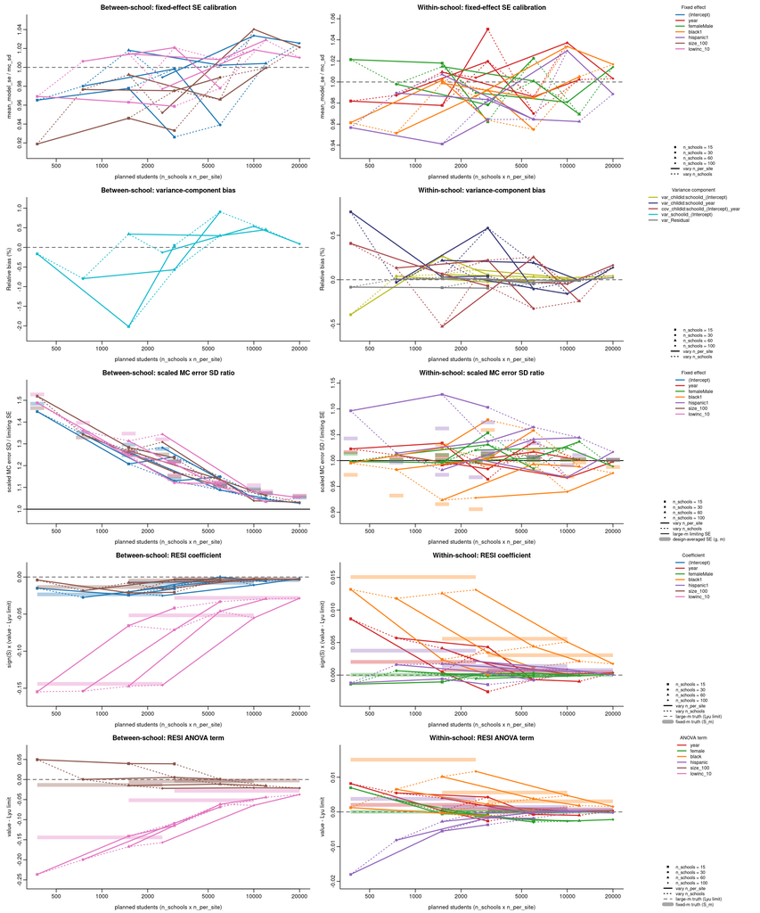

Model B (child-level random slope for year): the same panels as the Model A figure. Rows: fixed-effect SE ratio, variance-component relative bias (including the child slope variance and intercept-slope covariance), scaled Monte Carlo error SD / limiting SE with design-averaged SE ticks, and RESI coefficient and ANOVA-term simulation means relative to the Lyu-Welsh large-m truth, with the fixed-m truth S_m bands.

Model B: RESI point-estimator calibration by term, n_schools, and n_per_site

| n_schools | n_per_site | table | term | n | truth_resi | expected_resi_m | mc_mean_resi | bias_resi | mc_sd_resi |
| --- | --- | --- | --- | --- | --- | --- | --- | --- | --- |
| 15 | 25 | coefficients | (Intercept) | 15.000 | 0.115 | 0.092 | 0.100 | 0.015 | 0.280 |
| 15 | 25 | coefficients | year | 378.145 | 2.836 | 2.838 | 2.844 | -0.009 | 0.140 |
| 15 | 25 | coefficients | femaleMale | 378.145 | -0.010 | -0.010 | -0.009 | -0.001 | 0.051 |
| 15 | 25 | coefficients | black1 | 378.145 | -0.134 | -0.149 | -0.147 | 0.013 | 0.060 |
| 15 | 25 | coefficients | hispanic1 | 378.145 | -0.086 | -0.090 | -0.085 | -0.001 | 0.057 |
| 15 | 25 | coefficients | size_100 | 15.000 | -0.074 | -0.060 | -0.070 | -0.004 | 0.300 |
| 15 | 25 | coefficients | lowinc_10 | 15.000 | -0.632 | -0.488 | -0.477 | -0.155 | 0.313 |
| 15 | 25 | anova | year | 378.145 | 2.836 | 2.838 | 2.844 | -0.008 | 0.140 |
| 15 | 25 | anova | female | 378.145 | 0.010 | 0.010 | 0.017 | -0.007 | 0.032 |
| 15 | 25 | anova | black | 378.145 | 0.134 | 0.149 | 0.135 | -0.001 | 0.066 |
| 15 | 25 | anova | hispanic | 378.145 | 0.086 | 0.090 | 0.068 | 0.018 | 0.060 |
| 15 | 25 | anova | size_100 | 15.000 | 0.074 | 0.060 | 0.123 | -0.050 | 0.207 |
| 15 | 25 | anova | lowinc_10 | 15.000 | 0.632 | 0.488 | 0.396 | 0.236 | 0.334 |
| 30 | 25 | coefficients | (Intercept) | 30.000 | 0.115 | 0.092 | 0.088 | 0.028 | 0.187 |
| 30 | 25 | coefficients | year | 758.949 | 2.836 | 2.838 | 2.841 | -0.006 | 0.098 |
| 30 | 25 | coefficients | femaleMale | 758.949 | -0.010 | -0.010 | -0.011 | 0.001 | 0.037 |
| 30 | 25 | coefficients | black1 | 758.949 | -0.134 | -0.149 | -0.145 | 0.012 | 0.042 |
| 30 | 25 | coefficients | hispanic1 | 758.949 | -0.086 | -0.090 | -0.088 | 0.002 | 0.038 |
| 30 | 25 | coefficients | size_100 | 30.000 | -0.074 | -0.060 | -0.055 | -0.018 | 0.190 |
| 30 | 25 | coefficients | lowinc_10 | 30.000 | -0.632 | -0.488 | -0.478 | -0.154 | 0.201 |
| 30 | 25 | anova | year | 758.949 | 2.836 | 2.838 | 2.841 | -0.005 | 0.098 |
| 30 | 25 | anova | female | 758.949 | 0.010 | 0.010 | 0.014 | -0.003 | 0.023 |
| 30 | 25 | anova | black | 758.949 | 0.134 | 0.149 | 0.140 | -0.007 | 0.044 |
| 30 | 25 | anova | hispanic | 758.949 | 0.086 | 0.090 | 0.078 | 0.008 | 0.043 |
| 30 | 25 | anova | size_100 | 30.000 | 0.074 | 0.060 | 0.074 | 0.000 | 0.127 |
| 30 | 25 | anova | lowinc_10 | 30.000 | 0.632 | 0.488 | 0.433 | 0.200 | 0.223 |
| 60 | 25 | coefficients | (Intercept) | 60.000 | 0.115 | 0.092 | 0.095 | 0.020 | 0.129 |
| 60 | 25 | coefficients | year | 1503.051 | 2.836 | 2.838 | 2.840 | -0.004 | 0.071 |
| 60 | 25 | coefficients | femaleMale | 1503.051 | -0.010 | -0.010 | -0.010 | 0.000 | 0.025 |
| 60 | 25 | coefficients | black1 | 1503.051 | -0.134 | -0.149 | -0.146 | 0.013 | 0.028 |

[output cut: 126 more lines]

## 4.5 Confidence interval coverage

`tests/run_mixed_ci_coverage.R` reruns the hybrid plasmode on `n_schools` $\in \{15, 100\}$ × `n_per_site` $\in \{25, 200\}$ (1000 replicates each). For each replicate it computes the RESI intervals of `RESI:::.resi_ci_mixed()` (derivation: `notes/resi_mixed_ci.qmd`) with:

- the model-based covariance (`stats::vcov`, with the variance-component term), and
- the school-clustered CR2 covariance;

each with the normal, QF and CF methods (coefficients are signed, so QF equals normal there). Coverage is scored against the fixed-$m$ target $S_m$ (`expectedDesignResi`) and the large-$m$ Lyu limit $S_{\text{Lyu}}$. The grey band is $0.95 \pm 1.96$ Monte Carlo SE.

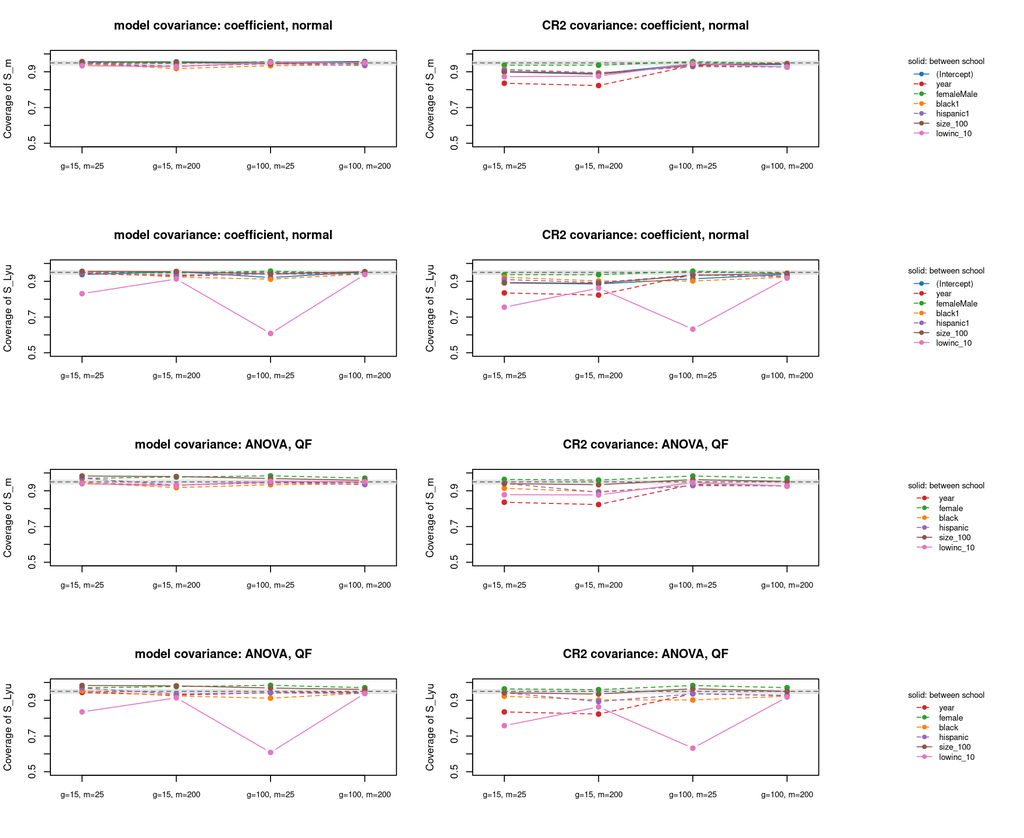

Coverage of S_m and S_Lyu by method (nominal 0.95; Monte Carlo SE 0.007)

| n_schools | n_per_site | table | term | covariance | coverage_S_m.normal | coverage_S_Lyu.normal | coverage_S_m.qf | coverage_S_Lyu.qf | coverage_S_m.cf | coverage_S_Lyu.cf |
| --- | --- | --- | --- | --- | --- | --- | --- | --- | --- | --- |
| 15 | 25 | anova | black | CR2 | 0.836 | 0.858 | 0.914 | 0.923 | 0.917 | 0.921 |
| 15 | 200 | anova | black | CR2 | 0.895 | 0.899 | 0.895 | 0.902 | 0.896 | 0.903 |
| 100 | 25 | anova | black | CR2 | 0.926 | 0.902 | 0.929 | 0.902 | 0.929 | 0.902 |
| 100 | 200 | anova | black | CR2 | 0.928 | 0.923 | 0.928 | 0.923 | 0.928 | 0.923 |
| 15 | 25 | anova | female | CR2 | 0.961 | 0.960 | 0.964 | 0.964 | 0.975 | 0.975 |
| 15 | 200 | anova | female | CR2 | 0.963 | 0.963 | 0.960 | 0.960 | 0.968 | 0.968 |
| 100 | 25 | anova | female | CR2 | 0.984 | 0.984 | 0.983 | 0.983 | 0.984 | 0.984 |
| 100 | 200 | anova | female | CR2 | 0.975 | 0.975 | 0.971 | 0.971 | 0.973 | 0.973 |
| 15 | 25 | anova | hispanic | CR2 | 0.970 | 0.967 | 0.942 | 0.943 | 0.968 | 0.962 |
| 15 | 200 | anova | hispanic | CR2 | 0.861 | 0.863 | 0.892 | 0.893 | 0.892 | 0.895 |
| 100 | 25 | anova | hispanic | CR2 | 0.902 | 0.908 | 0.930 | 0.936 | 0.931 | 0.937 |
| 100 | 200 | anova | hispanic | CR2 | 0.922 | 0.928 | 0.928 | 0.928 | 0.928 | 0.928 |
| 15 | 25 | anova | lowinc_10 | CR2 | 0.727 | 0.620 | 0.878 | 0.758 | 0.856 | 0.767 |
| 15 | 200 | anova | lowinc_10 | CR2 | 0.782 | 0.766 | 0.877 | 0.863 | 0.881 | 0.866 |
| 100 | 25 | anova | lowinc_10 | CR2 | 0.934 | 0.604 | 0.946 | 0.632 | 0.946 | 0.632 |
| 100 | 200 | anova | lowinc_10 | CR2 | 0.927 | 0.908 | 0.927 | 0.918 | 0.927 | 0.918 |
| 15 | 25 | anova | size_100 | CR2 | 0.959 | 0.964 | 0.940 | 0.942 | 0.955 | 0.960 |
| 15 | 200 | anova | size_100 | CR2 | 0.955 | 0.957 | 0.934 | 0.935 | 0.952 | 0.953 |
| 100 | 25 | anova | size_100 | CR2 | 0.979 | 0.988 | 0.963 | 0.965 | 0.973 | 0.982 |
| 100 | 200 | anova | size_100 | CR2 | 0.975 | 0.976 | 0.952 | 0.950 | 0.970 | 0.971 |
| 15 | 25 | anova | year | CR2 | 0.836 | 0.835 | 0.836 | 0.835 | 0.836 | 0.835 |
| 15 | 200 | anova | year | CR2 | 0.823 | 0.823 | 0.823 | 0.823 | 0.823 | 0.823 |
| 100 | 25 | anova | year | CR2 | 0.936 | 0.937 | 0.936 | 0.937 | 0.936 | 0.937 |
| 100 | 200 | anova | year | CR2 | 0.926 | 0.926 | 0.926 | 0.926 | 0.926 | 0.926 |
| 15 | 25 | anova | black | model | 0.879 | 0.896 | 0.945 | 0.953 | 0.948 | 0.951 |
| 15 | 200 | anova | black | model | 0.913 | 0.921 | 0.918 | 0.924 | 0.919 | 0.924 |
| 100 | 25 | anova | black | model | 0.929 | 0.915 | 0.934 | 0.912 | 0.934 | 0.912 |
| 100 | 200 | anova | black | model | 0.937 | 0.943 | 0.939 | 0.941 | 0.939 | 0.941 |
| 15 | 25 | anova | female | model | 0.970 | 0.970 | 0.970 | 0.970 | 0.972 | 0.972 |
| 15 | 200 | anova | female | model | 0.978 | 0.978 | 0.977 | 0.977 | 0.978 | 0.978 |

[output cut: 74 more lines]

Mean estimated SD of the coefficient RESI / Monte Carlo SD

| n_schools | n_per_site | term | ratio.model | ratio.CR2 |
| --- | --- | --- | --- | --- |
| 15 | 25 | (Intercept) | 0.975 | 0.787 |
| 15 | 25 | year | 0.967 | 0.691 |
| 15 | 25 | femaleMale | 0.992 | 0.924 |
| 15 | 25 | black1 | 1.008 | 0.798 |
| 15 | 25 | hispanic1 | 0.989 | 0.784 |
| 15 | 25 | size_100 | 0.939 | 0.740 |
| 15 | 25 | lowinc_10 | 0.914 | 0.704 |
| 100 | 25 | (Intercept) | 1.020 | 0.972 |
| 100 | 25 | year | 1.010 | 0.947 |
| 100 | 25 | femaleMale | 0.996 | 0.981 |
| 100 | 25 | black1 | 0.948 | 0.917 |
| 100 | 25 | hispanic1 | 0.991 | 0.944 |
| 100 | 25 | size_100 | 0.975 | 0.930 |
| 100 | 25 | lowinc_10 | 0.999 | 0.956 |
| 15 | 200 | (Intercept) | 0.941 | 0.759 |
| 15 | 200 | year | 0.914 | 0.669 |
| 15 | 200 | femaleMale | 1.008 | 0.913 |
| 15 | 200 | black1 | 0.950 | 0.756 |
| 15 | 200 | hispanic1 | 1.004 | 0.741 |
| 15 | 200 | size_100 | 0.945 | 0.742 |
| 15 | 200 | lowinc_10 | 0.863 | 0.739 |
| 100 | 200 | (Intercept) | 1.009 | 0.950 |
| 100 | 200 | year | 0.991 | 0.927 |
| 100 | 200 | femaleMale | 0.974 | 0.964 |
| 100 | 200 | black1 | 0.991 | 0.914 |
| 100 | 200 | hispanic1 | 0.984 | 0.924 |
| 100 | 200 | size_100 | 1.007 | 0.958 |
| 100 | 200 | lowinc_10 | 0.994 | 0.954 |

### 4.5.1 Full design grid (Model A)

The same simulation on the full grid `n_schools` $\in \{15, 30, 60, 100\}$ × `n_per_site` $\in \{25, 100, 200\}$ (lmer only, 1000 replicates per cell, seed 2027, `resi.coverage.tag = "_grid"`). It also includes CR2 with the $t_{g-1}$ / $F(\cdot, g-1)$ reference (“CR2-t”), which is now the package default for cluster-robust intervals (next subsection). Each panel shows the mean coverage of $S_m$ over the non-intercept terms (solid) and the minimum over terms (dotted), against `n_schools`, with one color per `n_per_site`.

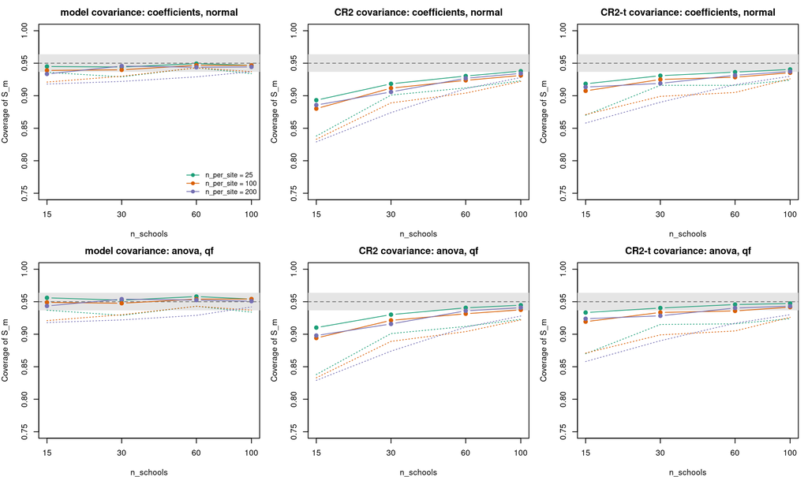

Model A grid: coverage of S_m, mean / minimum over non-intercept terms

| table | method | n_schools | n_per_site | CR2 | CR2-t | model |
| --- | --- | --- | --- | --- | --- | --- |
| anova | cf | 15 | 25 | 0.917 / 0.838 | 0.947 / 0.870 | 0.950 / 0.872 |
| anova | cf | 15 | 100 | 0.897 / 0.834 | 0.925 / 0.871 | 0.949 / 0.922 |
| anova | cf | 15 | 200 | 0.903 / 0.829 | 0.928 / 0.858 | 0.946 / 0.919 |
| anova | cf | 30 | 25 | 0.923 / 0.879 | 0.946 / 0.915 | 0.944 / 0.891 |
| anova | cf | 30 | 100 | 0.922 / 0.888 | 0.935 / 0.900 | 0.949 / 0.930 |
| anova | cf | 30 | 200 | 0.918 / 0.874 | 0.931 / 0.891 | 0.955 / 0.922 |
| anova | cf | 60 | 25 | 0.943 / 0.912 | 0.947 / 0.916 | 0.959 / 0.944 |
| anova | cf | 60 | 100 | 0.933 / 0.904 | 0.939 / 0.905 | 0.956 / 0.943 |
| anova | cf | 60 | 200 | 0.939 / 0.911 | 0.943 / 0.917 | 0.955 / 0.929 |
| anova | cf | 100 | 25 | 0.948 / 0.923 | 0.950 / 0.924 | 0.956 / 0.934 |
| anova | cf | 100 | 100 | 0.940 / 0.922 | 0.944 / 0.926 | 0.956 / 0.937 |
| anova | cf | 100 | 200 | 0.944 / 0.928 | 0.946 / 0.931 | 0.954 / 0.942 |
| anova | normal | 15 | 25 | 0.881 / 0.737 | 0.899 / 0.750 | 0.922 / 0.780 |
| anova | normal | 15 | 100 | 0.866 / 0.769 | 0.888 / 0.791 | 0.915 / 0.822 |
| anova | normal | 15 | 200 | 0.882 / 0.791 | 0.899 / 0.808 | 0.922 / 0.836 |
| anova | normal | 30 | 25 | 0.893 / 0.786 | 0.907 / 0.824 | 0.913 / 0.806 |
| anova | normal | 30 | 100 | 0.910 / 0.857 | 0.918 / 0.867 | 0.933 / 0.873 |
| anova | normal | 30 | 200 | 0.914 / 0.874 | 0.923 / 0.891 | 0.948 / 0.910 |
| anova | normal | 60 | 25 | 0.928 / 0.876 | 0.932 / 0.884 | 0.946 / 0.900 |
| anova | normal | 60 | 100 | 0.931 / 0.904 | 0.935 / 0.905 | 0.953 / 0.931 |
| anova | normal | 60 | 200 | 0.939 / 0.910 | 0.944 / 0.916 | 0.954 / 0.922 |
| anova | normal | 100 | 25 | 0.943 / 0.907 | 0.944 / 0.908 | 0.951 / 0.916 |
| anova | normal | 100 | 100 | 0.941 / 0.922 | 0.944 / 0.926 | 0.954 / 0.932 |
| anova | normal | 100 | 200 | 0.944 / 0.926 | 0.947 / 0.928 | 0.954 / 0.935 |
| anova | qf | 15 | 25 | 0.910 / 0.838 | 0.933 / 0.870 | 0.956 / 0.937 |
| anova | qf | 15 | 100 | 0.894 / 0.833 | 0.919 / 0.871 | 0.949 / 0.921 |
| anova | qf | 15 | 200 | 0.898 / 0.829 | 0.924 / 0.858 | 0.944 / 0.918 |
| anova | qf | 30 | 25 | 0.930 / 0.901 | 0.940 / 0.915 | 0.952 / 0.929 |
| anova | qf | 30 | 100 | 0.921 / 0.889 | 0.933 / 0.899 | 0.948 / 0.930 |
| anova | qf | 30 | 200 | 0.916 / 0.874 | 0.928 / 0.890 | 0.954 / 0.922 |
| anova | qf | 60 | 25 | 0.941 / 0.912 | 0.946 / 0.916 | 0.958 / 0.943 |
| anova | qf | 60 | 100 | 0.931 / 0.904 | 0.936 / 0.905 | 0.954 / 0.943 |
| anova | qf | 60 | 200 | 0.936 / 0.911 | 0.940 / 0.917 | 0.953 / 0.929 |
| anova | qf | 100 | 25 | 0.945 / 0.923 | 0.947 / 0.924 | 0.954 / 0.934 |
| anova | qf | 100 | 100 | 0.938 / 0.922 | 0.942 / 0.926 | 0.954 / 0.937 |
| anova | qf | 100 | 200 | 0.941 / 0.928 | 0.943 / 0.930 | 0.951 / 0.942 |
| coefficients | normal | 15 | 25 | 0.893 / 0.838 | 0.918 / 0.870 | 0.945 / 0.936 |
| coefficients | normal | 15 | 100 | 0.880 / 0.833 | 0.907 / 0.871 | 0.939 / 0.921 |
| coefficients | normal | 15 | 200 | 0.886 / 0.829 | 0.913 / 0.858 | 0.933 / 0.918 |
| coefficients | normal | 30 | 25 | 0.918 / 0.901 | 0.931 / 0.916 | 0.944 / 0.929 |
| coefficients | normal | 30 | 100 | 0.912 / 0.889 | 0.925 / 0.899 | 0.940 / 0.930 |
| coefficients | normal | 30 | 200 | 0.906 / 0.874 | 0.919 / 0.890 | 0.946 / 0.922 |
| coefficients | normal | 60 | 25 | 0.930 / 0.912 | 0.936 / 0.916 | 0.949 / 0.943 |
| coefficients | normal | 60 | 100 | 0.924 / 0.904 | 0.928 / 0.905 | 0.947 / 0.943 |
| coefficients | normal | 60 | 200 | 0.927 / 0.911 | 0.931 / 0.917 | 0.944 / 0.929 |
| coefficients | normal | 100 | 25 | 0.938 / 0.923 | 0.941 / 0.924 | 0.947 / 0.934 |
| coefficients | normal | 100 | 100 | 0.931 / 0.922 | 0.935 / 0.926 | 0.947 / 0.937 |
| coefficients | normal | 100 | 200 | 0.934 / 0.928 | 0.937 / 0.930 | 0.944 / 0.937 |
| coefficients | qf | 15 | 25 | 0.893 / 0.838 | 0.918 / 0.870 | 0.945 / 0.936 |
| coefficients | qf | 15 | 100 | 0.880 / 0.833 | 0.907 / 0.871 | 0.939 / 0.921 |
| coefficients | qf | 15 | 200 | 0.886 / 0.829 | 0.913 / 0.858 | 0.933 / 0.918 |
| coefficients | qf | 30 | 25 | 0.918 / 0.901 | 0.931 / 0.916 | 0.944 / 0.929 |
| coefficients | qf | 30 | 100 | 0.912 / 0.889 | 0.925 / 0.899 | 0.940 / 0.930 |
| coefficients | qf | 30 | 200 | 0.906 / 0.874 | 0.919 / 0.890 | 0.946 / 0.922 |
| coefficients | qf | 60 | 25 | 0.930 / 0.912 | 0.936 / 0.916 | 0.949 / 0.943 |
| coefficients | qf | 60 | 100 | 0.924 / 0.904 | 0.928 / 0.905 | 0.947 / 0.943 |
| coefficients | qf | 60 | 200 | 0.927 / 0.911 | 0.931 / 0.917 | 0.944 / 0.929 |
| coefficients | qf | 100 | 25 | 0.938 / 0.923 | 0.941 / 0.924 | 0.947 / 0.934 |
| coefficients | qf | 100 | 100 | 0.931 / 0.922 | 0.935 / 0.926 | 0.947 / 0.937 |
| coefficients | qf | 100 | 200 | 0.934 / 0.928 | 0.937 / 0.930 | 0.944 / 0.937 |

With the model-based covariance, the QF and CF intervals cover close to nominal in every cell (cell means 0.944-0.959), and so do the coefficient intervals (0.933-0.949). The normal ANOVA interval undercovers near-boundary terms at small `n_schools`, as before. CR2-t coverage rises steadily with `n_schools`: mean coefficient coverage is about 0.91-0.92 at 15 schools, 0.92-0.93 at 30, 0.93-0.94 at 60 and 0.94 at 100. Plain CR2 is 0.01-0.03 lower at `n_schools` $\le 30$. `n_per_site` has little effect.

### 4.5.2 Model B coverage

The same coverage simulation for Model B (child-level random slope for `year`; 2×2 corner cells, lmer only, 1000 replicates, seed 2027). The `lme` refit is not used because it assumes random intercepts only.

Model B: coverage of S_m, mean / minimum over non-intercept terms

| table | method | n_schools | n_per_site | CR2 | CR2-t | model |
| --- | --- | --- | --- | --- | --- | --- |
| anova | cf | 15 | 25 | 0.930 / 0.829 | 0.953 / 0.869 | 0.965 / 0.931 |
| anova | cf | 15 | 200 | 0.900 / 0.825 | 0.929 / 0.856 | 0.942 / 0.887 |
| anova | cf | 100 | 25 | 0.946 / 0.924 | 0.950 / 0.928 | 0.956 / 0.937 |
| anova | cf | 100 | 200 | 0.945 / 0.925 | 0.947 / 0.927 | 0.951 / 0.933 |
| anova | normal | 15 | 25 | 0.916 / 0.828 | 0.934 / 0.848 | 0.954 / 0.868 |
| anova | normal | 15 | 200 | 0.874 / 0.757 | 0.896 / 0.777 | 0.926 / 0.803 |
| anova | normal | 100 | 25 | 0.945 / 0.917 | 0.948 / 0.922 | 0.955 / 0.933 |
| anova | normal | 100 | 200 | 0.946 / 0.922 | 0.948 / 0.925 | 0.953 / 0.932 |
| anova | qf | 15 | 25 | 0.911 / 0.829 | 0.934 / 0.868 | 0.955 / 0.931 |
| anova | qf | 15 | 200 | 0.896 / 0.825 | 0.921 / 0.856 | 0.949 / 0.925 |
| anova | qf | 100 | 25 | 0.945 / 0.923 | 0.948 / 0.927 | 0.954 / 0.937 |
| anova | qf | 100 | 200 | 0.941 / 0.925 | 0.943 / 0.927 | 0.947 / 0.933 |
| coefficients | normal | 15 | 25 | 0.895 / 0.829 | 0.922 / 0.869 | 0.945 / 0.931 |
| coefficients | normal | 15 | 200 | 0.883 / 0.825 | 0.910 / 0.856 | 0.940 / 0.925 |
| coefficients | normal | 100 | 25 | 0.938 / 0.923 | 0.942 / 0.927 | 0.948 / 0.937 |
| coefficients | normal | 100 | 200 | 0.936 / 0.925 | 0.939 / 0.927 | 0.942 / 0.933 |
| coefficients | qf | 15 | 25 | 0.895 / 0.829 | 0.922 / 0.869 | 0.945 / 0.931 |
| coefficients | qf | 15 | 200 | 0.883 / 0.825 | 0.910 / 0.856 | 0.940 / 0.925 |
| coefficients | qf | 100 | 25 | 0.938 / 0.923 | 0.942 / 0.927 | 0.948 / 0.937 |
| coefficients | qf | 100 | 200 | 0.936 / 0.925 | 0.939 / 0.927 | 0.942 / 0.933 |

Model B: mean estimated SD of the coefficient RESI / Monte Carlo SD

| n_schools | n_per_site | term | ratio.model | ratio.CR2 |
| --- | --- | --- | --- | --- |
| 15 | 25 | (Intercept) | 0.981 | 0.778 |
| 15 | 25 | year | 0.929 | 0.681 |
| 15 | 25 | femaleMale | 0.980 | 0.914 |
| 15 | 25 | black1 | 1.000 | 0.804 |
| 15 | 25 | hispanic1 | 0.986 | 0.772 |
| 15 | 25 | size_100 | 0.943 | 0.744 |
| 15 | 25 | lowinc_10 | 0.927 | 0.703 |
| 100 | 25 | (Intercept) | 1.013 | 0.978 |
| 100 | 25 | year | 0.998 | 0.929 |
| 100 | 25 | femaleMale | 1.005 | 0.989 |
| 100 | 25 | black1 | 0.951 | 0.916 |
| 100 | 25 | hispanic1 | 1.001 | 0.943 |
| 100 | 25 | size_100 | 0.975 | 0.933 |
| 100 | 25 | lowinc_10 | 0.995 | 0.948 |
| 15 | 200 | (Intercept) | 0.965 | 0.753 |
| 15 | 200 | year | 0.935 | 0.644 |
| 15 | 200 | femaleMale | 1.024 | 0.928 |
| 15 | 200 | black1 | 0.953 | 0.768 |
| 15 | 200 | hispanic1 | 0.988 | 0.687 |
| 15 | 200 | size_100 | 0.942 | 0.752 |
| 15 | 200 | lowinc_10 | 0.912 | 0.764 |
| 100 | 200 | (Intercept) | 0.987 | 0.953 |
| 100 | 200 | year | 0.966 | 0.941 |
| 100 | 200 | femaleMale | 0.976 | 0.962 |
| 100 | 200 | black1 | 0.985 | 0.928 |
| 100 | 200 | hispanic1 | 0.972 | 0.913 |
| 100 | 200 | size_100 | 0.994 | 0.958 |
| 100 | 200 | lowinc_10 | 1.015 | 0.956 |

The model-based coefficient, QF and CF intervals cover at 0.94-0.97 on average in every cell. The normal ANOVA interval again undercovers at 15 schools (0.93). `year` covers at 0.93-0.95, so the random-slope sample-size rule (n = number of children) gives correctly scaled intervals. With 15 schools, CR2 underestimates the SD of the RESI more than in Model A (ratios 0.64-0.93; `year` 0.64-0.68), so even CR2-t covers only 0.86-0.87 for `year` (cell means 0.91-0.95). At 100 schools CR2 and CR2-t cover at 0.93-0.95.

### 4.5.3 Finite-df reference for CR2 (package default)

The CR2 rows above use normal / $\chi^2$ references. Because the CR2 meat is estimated from only $g$ clusters, the package now uses a $t_{g-1}$ / $F(\cdot, g-1)$ reference automatically for cluster-robust intervals. Model-based intervals are unchanged (see `notes/resi_mixed_ci.qmd`, “Finite-df reference”). `tests/run_cr2_reference_eval.R` compares the two references at `n_schools = 15` (1000 replicates per cell) on egsingle and on `mlmRev::star` (fresh seeds). The evaluation used a 200-point midpoint rule over $W$. The package uses 20-node Gauss–Laguerre, which differs by at most $3 \times 10^{-4}$ in tail probability.

Coverage of S_m at n_schools = 15, CR2 with normal vs t(g - 1) reference: mean and minimum over non-intercept terms

| dataset | n_per_site | table | method | mean.CR2 | min.CR2 | mean.CR2-t | min.CR2-t |
| --- | --- | --- | --- | --- | --- | --- | --- |
| egsingle | 25 | anova | cf | 0.918 | 0.836 | 0.948 | 0.871 |
| star | 25 | anova | cf | 0.918 | 0.859 | 0.943 | 0.892 |
| egsingle | 200 | anova | cf | 0.902 | 0.823 | 0.928 | 0.855 |
| star | 200 | anova | cf | 0.898 | 0.865 | 0.931 | 0.893 |
| egsingle | 25 | anova | normal | 0.881 | 0.727 | 0.901 | 0.742 |
| star | 25 | anova | normal | 0.887 | 0.769 | 0.905 | 0.793 |
| egsingle | 200 | anova | normal | 0.880 | 0.782 | 0.899 | 0.802 |
| star | 200 | anova | normal | 0.878 | 0.832 | 0.905 | 0.863 |
| egsingle | 25 | coefficients | normal | 0.895 | 0.836 | 0.920 | 0.871 |
| star | 25 | coefficients | normal | 0.895 | 0.859 | 0.921 | 0.892 |
| egsingle | 200 | coefficients | normal | 0.885 | 0.823 | 0.914 | 0.855 |
| star | 200 | coefficients | normal | 0.886 | 0.865 | 0.915 | 0.893 |
| egsingle | 25 | anova | qf | 0.912 | 0.836 | 0.935 | 0.871 |
| star | 25 | anova | qf | 0.908 | 0.859 | 0.934 | 0.892 |
| egsingle | 200 | anova | qf | 0.897 | 0.823 | 0.923 | 0.855 |
| star | 200 | anova | qf | 0.897 | 0.865 | 0.926 | 0.892 |

The $t_{g-1}$ reference raises mean coverage by about 0.03 in both datasets without over-covering (maximum about 0.98). The intercept is essentially unchanged: its under-coverage at small $g$ comes from skewness and SE under-estimation, not from the quantile.

### 4.5.4 `nlme::lme` fits

Each replicate is also refitted with `nlme::lme(fixed, random = ~ 1 | schoolid/childid, method = "REML")` (the replicate lmer fits are also REML) and passed through `resi()`’s lme path, which maps the fit to the same $V = \sigma^2(I + Z\Lambda\Lambda^\top Z^\top)$ representation as lmer (see `notes/resi_mixed_ci.qmd`). The two engines optimise the same likelihood with different optimisers, so the intervals should agree up to the optimiser tolerance, and so should the coverage.

Results:

Maximum |lme - lmer| difference over replicates and terms, per cell

| n_schools | n_per_site | n_rep | covariance | method | d_est | d_lower | d_upper |
| --- | --- | --- | --- | --- | --- | --- | --- |
| 15 | 25 | 1000 | CR2 | cf | 0.00019258 | 0.00037670 | 0.00044306 |
| 15 | 25 | 1000 | model | cf | 0.00033680 | 0.23140359 | 0.13441970 |
| 15 | 25 | 1000 | CR2 | normal | 0.00019258 | 0.00044116 | 0.06929596 |
| 15 | 25 | 1000 | model | normal | 0.00033680 | 0.13429511 | 0.13429141 |
| 15 | 25 | 1000 | CR2 | qf | 0.00019258 | 0.00044116 | 0.00044116 |
| 15 | 25 | 1000 | model | qf | 0.00033680 | 0.13445040 | 0.13429141 |
| 100 | 25 | 931 | CR2 | cf | 0.00000692 | 0.00000884 | 0.00000891 |
| 100 | 25 | 931 | model | cf | 0.00002246 | 0.00002257 | 0.00002435 |
| 100 | 25 | 931 | CR2 | normal | 0.00000692 | 0.00000891 | 0.00000900 |
| 100 | 25 | 931 | model | normal | 0.00002246 | 0.00002436 | 0.00002453 |
| 100 | 25 | 931 | CR2 | qf | 0.00000692 | 0.00000891 | 0.00003898 |
| 100 | 25 | 931 | model | qf | 0.00002246 | 0.00002436 | 0.00002436 |
| 15 | 200 | 920 | CR2 | cf | 0.00012180 | 0.00016909 | 0.00016995 |
| 15 | 200 | 920 | model | cf | 0.00020028 | 0.00021098 | 0.00020865 |
| 15 | 200 | 920 | CR2 | normal | 0.00012180 | 0.00017095 | 0.00016380 |
| 15 | 200 | 920 | model | normal | 0.00020028 | 0.00021369 | 0.00021047 |
| 15 | 200 | 920 | CR2 | qf | 0.00012180 | 0.00017095 | 0.00017096 |
| 15 | 200 | 920 | model | qf | 0.00020028 | 0.00021034 | 0.00021047 |
| 100 | 200 | 809 | CR2 | cf | 0.00000276 | 0.00000298 | 0.00000284 |
| 100 | 200 | 809 | model | cf | 0.00005188 | 0.00005133 | 0.00005166 |
| 100 | 200 | 809 | CR2 | normal | 0.00000276 | 0.00000303 | 0.00000299 |
| 100 | 200 | 809 | model | normal | 0.00005188 | 0.00005169 | 0.00005240 |
| 100 | 200 | 809 | CR2 | qf | 0.00000276 | 0.00000299 | 0.00000299 |
| 100 | 200 | 809 | model | qf | 0.00005188 | 0.00005169 | 0.00005169 |

Coverage of lme intervals relative to lmer intervals

| quantity | value |
| --- | --- |
| rows compared | 312.0000 |
| lme replicates per row (min) | 809.0000 |
| max \|coverage S_m lme - lmer\| | 0.0116 |
| max \|coverage S_Lyu lme - lmer\| | 0.0090 |

## 4.6 Interpretation

- **Fixed-effect SE calibration and variance-component bias** are shown across the joint `n_schools` by `n_per_site` grid in a single panel per diagnostic, plotted against the planned total student count.
- The RESI rows separate the two sources of discrepancy from the large-$m$ target. The band ($S_m$ minus the Lyu limit) is the finite-$m$ estimand gap. It is large for between-school terms, small for partly clustered student covariates (`black`, `hispanic`), and essentially zero for `year` and `female`, and it shrinks as `n_per_site` grows. The distance from the points to the band is estimator bias at fixed $m$. It is negligible for coefficients. For ANOVA terms it is about $1/(2 S n)$, from the $-\mathrm{df}$ correction, truncation and square root, so it shrinks with `n_schools` for between-school terms. This approximation needs $S\sqrt{n}$ to be large; for near-null terms (`female`, and `size_100` at small `n_schools`) truncation at zero dominates instead. These are point-estimator diagnostics; interval coverage is in the next bullet.
- **CI coverage.** With the model-based covariance, coverage of $S_m$ is close to 0.95 in every cell (cell means 0.94-0.96; the lowest values, about 0.90-0.92, are for `black`/`hispanic` and `lowinc_10` at `n_schools = 15`). The normal ANOVA interval undercovers the near-boundary terms at `n_schools = 15`; QF and CF do not. With CR2, coverage is 0.82-0.94 at `n_schools = 15`, because the estimated SD of the RESI underestimates its Monte Carlo SD by 20-30% there (the usual few-cluster behaviour), and 0.93-0.95 at `n_schools = 100`. The CR2 RESI is much more variable than the model-based one for terms with a large RESI and a small SE (e.g. `year`: Monte Carlo SD 0.29 vs 0.03 at `n_schools = 100`, `n_per_site = 200`). The school-level meat is estimated from only `n_schools` clusters, and the intervals reflect that variability. The package default for CR2 uses a $t_{g-1}$ reference, which raises coverage by about 0.03 at 15 schools and 0.01 at 30; across the full grid, CR2-t coverage rises steadily towards 0.95 as `n_schools` grows. Model B (random slope) behaves like Model A with the model-based covariance. Its CR2 intervals undercover more at 15 schools. Coverage of $S_{\text{Lyu}}$ matches coverage of $S_m$ for within-school terms. For between-school terms it drops where the fixed-$m$ gap is large relative to the interval width (`lowinc_10`: about 0.6 at `n_schools = 100`, `n_per_site = 25`), which is a property of the estimand, not of the interval.

# 5 Open questions / next steps

- Simon’s slope-heterogeneity hypothesis (see Purpose) has not been confirmed directly for every term affected under full resampling of the real data. Model A contains no random slopes. Model B adds a child-level slope for `year` only; slopes for other terms, or school-level slopes, are not simulated.
- For 100 schools, source-school covariate profiles are sampled repeatedly from the observed 60-school empirical distribution. Assessing sensitivity to this finite school-profile pool remains an interpretation caveat.